# Welcome to Session 03 [Convolutional Neural Network (CNN)]

This is a [Google Colaboratory](https://colab.research.google.com/notebooks/welcome.ipynb) notebook file. Python programs are run directly in the browser—a great way to learn and use TensorFlow. To follow this tutorial, run the notebook in Google Colab by clicking the button at the top of this page.

1. In Colab, connect to a Python runtime: At the top-right of the menu bar, select *CONNECT*.
2. Run all the notebook code cells: Select *Runtime* > *Run all*.

# Overview

Architecture of a traditional CNN ― Convolutional neural networks, also known as CNNs, are a specific type of neural networks that are generally composed of the following layers:

[figure not shown]

# Types of Layer

**Convolution layer (CONV)** ― The convolution layer (CONV) uses filters that perform convolution operations as it is scanning the input I with respect to its dimensions. Its hyperparameters include the filter size F and stride S. The resulting output O is called feature map or activation map.

[figure not shown]

Remark: the convolution step can be generalized to the 1D and 3D cases as well.

**Pooling (POOL)** ― The pooling layer (POOL) is a downsampling operation, typically applied after a convolution layer, which does some spatial invariance. In particular, max and average pooling are special kinds of pooling where the maximum and average value is taken, respectively.

**Type**

**Max pooling**

**Average pooling**

**Purpose**

Each pooling operation selects the maximum value of the current view

Each pooling operation averages the values of the current view

**Illustration**

[figure not shown]

**Comments**

- Preserves detected features
- Most commonly used
- Downsamples feature map
- Used in LeNet

**Fully Connected (FC)** ― The fully connected layer (FC) operates on a flattened input where each input is connected to all neurons. If present, FC layers are usually found towards the end of CNN architectures and can be used to optimize objectives such as class scores.

[figure not shown]

## Filter hyperparameters

The convolution layer contains filters for which it is important to know the meaning behind its hyperparameters.

**Dimensions of a filter** ― A filter of size F×F applied to an input containing C channels is a F×F×C volume that performs convolutions on an input of size I×I×C and produces an output feature map (also called activation map) of size O×O×1.

[figure not shown]

Remark: the application of K filters of size F×F results in an output feature map of size O×O×K.

**Stride** ― For a convolutional or a pooling operation, the stride S denotes the number of pixels by which the window moves after each operation.

[figure not shown]

**Zero-padding** ― Zero-padding denotes the process of adding P zeroes to each side of the boundaries of the input. This value can either be manually specified or automatically set through one of the three modes detailed below:

**Mode**

Valid

Same

Full

**Illustration**

[figure not shown]

**Purpose**

- No padding
- Drops last convolution if dimensions do not match
- Output size is mathematically convenient
- Also called 'half' padding
- Maximum padding such that end convolutions are applied on the limits of the input
- Filter 'sees' the input end-to-end

## Commonly used activation functions

**Rectified Linear Unit** ― The rectified linear unit layer (ReLU) is an activation function g that is used on all elements of the volume. It aims at introducing non-linearities to the network. Its variants are summarized in the table below:

| **ReLU** | **Leaky ReLU** | **ELU** |
| --- | --- | --- |
| $$g(z)=\max(0,z)$$ | $$g(z)=\max(\epsilon z,z) \\ with\quad \epsilon\ll1$$ | $$g(z)=\max(\alpha(e^z-1),z) \\ with\quad \alpha\ll1$$ |
| • Non-linearity complexities biologically interpretable | • Addresses dying ReLU issue for negative values | • Differentiable everywhere |

**Softmax** ― The softmax step can be seen as a generalized logistic function that takes as input a vector of scores x∈Rn and outputs a vector of output probability p∈Rn through a softmax function at the end of the architecture. It is defined as follows:

$$\boxed{p=\begin{pmatrix}p_1\\\vdots\\p_n\end{pmatrix}}\quad\textrm{where}\quad\boxed{p_i=\frac{e^{x_i}}{\displaystyle\sum_{j=1}^ne^{x_j}}}$$

# Implementing The Model

## Initialization

### Mounting

```python
# Mounting Gdrive

USE_G_COLAB = True

if USE_G_COLAB:
    from google.colab import drive


    drive.mount('/content/drive', force_remount=True)
```

```
Go to this URL in a browser: https://accounts.google.com/o/oauth2/auth?client_id=947318989803-6bn6qk8qdgf4n4g3pfee6491hc0brc4i.apps.googleusercontent.com&redirect_uri=urn%3Aietf%3Awg%3Aoauth%3A2.0%3Aoob&scope=email%20https%3A%2F%2Fwww.googleapis.com%2Fauth%2Fdocs.test%20https%3A%2F%2Fwww.googleapis.…

Enter your authorization code:
··········
```

```python
# Project Root

root_dir = ''

if USE_G_COLAB:
    root_dir = '/content/drive/My Drive/workshops/2019_07_21/sessions_01/'
    # root_dir = '/content/drive/My Drive/dl_app/'
```

### Install Requirement

```python
!pip install -q tensorflow-gpu==2.0.0-beta1
!pip install -qU watermark
```

```
     |████████████████████████████████| 348.9MB 77kB/s
     |████████████████████████████████| 501kB 42.5MB/s
     |████████████████████████████████| 3.1MB 38.0MB/s
```

### Custom Matplotlib Style

```python
mpl_style = "https://gist.githubusercontent.com/m3hrdadfi/af8aca01094afb7d3e5b46de9ad8d509/raw/871ec5d721a3b438c3c896718ea4aafc91ea9744/gadfly.mplstyle"

!wget -q $mpl_style -O /root/.config/matplotlib/matplotlibrc
```

### General Paramas

A random seed is a number used to initialize a pseudorandom number generator. For a seed to be used in a pseudorandom number generator, it does not need to be random

```python
RANDOM_SEED = 141
```

### Import requried packages

```python
import tensorflow as tf

import requests
import numpy as np
import pandas as pd

from sklearn.model_selection import train_test_split
from sklearn.preprocessing import StandardScaler
from sklearn.metrics import classification_report, confusion_matrix
from sklearn.utils import shuffle

import matplotlib as mpl
import matplotlib.pyplot as plt

import cv2

import random
import sys
import io
import re
import time
from datetime import datetime
import os
import struct
import itertools
from tqdm import tqdm

from pprint import pprint


%matplotlib inline
mpl.rc_file(mpl.matplotlib_fname())

%load_ext tensorboard
```

## Persian MNIST

Attribute Information:

1. pixels
2. class:
   - 0
   - 1
   - 2
   - 3
   - 4
   - 5
   - 6
   - 7
   - 8
   - 9

```python
!wget https://www.dropbox.com/s/op3ht07lfou9lbz/DigitDB.zip
!unzip DigitDB.zip
!ls
```

[output not shown]

```python
def resize_image(src_image, dst_image_height, dst_image_width):
    src_image_height = src_image.shape[0]
    src_image_width = src_image.shape[1]

    if src_image_height > dst_image_height or src_image_width > dst_image_width:
        height_scale = dst_image_height / src_image_height
        width_scale = dst_image_width / src_image_width
        scale = min(height_scale, width_scale)
        img = cv2.resize(src=src_image, dsize=(0, 0), fx=scale, fy=scale, interpolation=cv2.INTER_CUBIC)
    else:
        img = src_image

    img_height = img.shape[0]
    img_width = img.shape[1]

    dst_image = np.zeros(shape=[dst_image_height, dst_image_width], dtype=np.uint8)

    y_offset = (dst_image_height - img_height) // 2
    x_offset = (dst_image_width - img_width) // 2

    dst_image[y_offset:y_offset + img_height, x_offset:x_offset + img_width] = img

    return dst_image


def read_cdb(filepath):
    with open(filepath, 'rb') as f:
        data = f.read()
        offset = 0

        # read private header
        yy = struct.unpack_from('H', data, offset)[0]
        offset += 2

        m = struct.unpack_from('B', data, offset)[0]
        offset += 1

        d = struct.unpack_from('B', data, offset)[0]
        offset += 1

        h = struct.unpack_from('B', data, offset)[0]
        offset += 1

        w = struct.unpack_from('B', data, offset)[0]
        offset += 1

        total_rec = struct.unpack_from('I', data, offset)[0]
        offset += 4

        letter_count = struct.unpack_from('128I', data, offset)
        offset += 128 * 4

        img_type = struct.unpack_from('B', data, offset)[0]  # 0: binary, 1: gray
        offset += 1

        comments = struct.unpack_from('256c', data, offset)
        offset += 256 * 1

        reserved = struct.unpack_from('245c', data, offset)
        offset += 245 * 1

        if (w > 0) and (h > 0):
            normal = True
        else:
            normal = False

        images = []
        labels = []

        for i in tqdm(range(total_rec), position=0):

            start_byte = struct.unpack_from('B', data, offset)[0]  # must be 0xff
            offset += 1

            label = struct.unpack_from('B', data, offset)[0]
            offset += 1

            if not normal:
                w = struct.unpack_from('B', data, offset)[0]
                offset += 1

                h = struct.unpack_from('B', data, offset)[0]
                offset += 1

            byte_count = struct.unpack_from('H', data, offset)[0]
            offset += 2

            image = np.zeros(shape=[h, w], dtype=np.uint8)

            if img_type == 0:
                # Binary
                for y in range(h):
                    b_white = True
                    counter = 0
                    while counter < w:
                        wb_count = struct.unpack_from('B', data, offset)[0]
                        offset += 1

                        if b_white:
                            image[y, counter:counter + wb_count] = 0  # Background
                        else:
                            image[y, counter:counter + wb_count] = 255  # ForeGround
                        b_white = not b_white  # black white black white ...
                        counter += wb_count
            else:
                # GrayScale mode
                data = struct.unpack_from('{}B'.format(w * h), data, offset)
                offset += w * h
                image = np.asarray(data, dtype=np.uint8).reshape([w, h]).T

            images.append(image)
            labels.append(label)

        return images, labels


def load_data(datapath, img_height=32, img_width=32):
    images, labels = read_cdb(datapath)
    assert len(images) == len(labels)

    x = np.zeros(shape=[len(images), img_height, img_width], dtype=np.float32)
    y = np.zeros(shape=[len(labels)], dtype=np.int)

    for i in tqdm(range(len(images)), position=0):
        image = images[i]
        image = resize_image(src_image=image, dst_image_height=img_height, dst_image_width=img_width)
        image = image / 255
        image = np.where(image >= 0.5, 1, 0)

        x[i] = image
        y[i] = labels[i]

    x, y = shuffle(x, y, random_state=0)

    return x, y
```

# Load the data

```python
trainset_dir = 'Train 60000.cdb'
testset_dir = 'Test 20000.cdb'

x_train, y_train = load_data(trainset_dir)
x_test, y_test = load_data(testset_dir)

print('Train: %s, Labels: #%s' %(x_train.shape, len(y_train)))
print('Test: %s, Labels: #%s' %(x_test.shape, len(y_test)))
```

```
Train: (60000, 32, 32), Labels: #60000
Test: (20000, 32, 32), Labels: #20000
```

```python
x_train, x_valid, y_train, y_valid = train_test_split(x_train, y_train, test_size=0.05, random_state=RANDOM_SEED)

print('Train: %s, Labels: #%s' %(x_train.shape, len(y_train)))
print('Valid: %s, Labels: #%s' %(x_valid.shape, len(y_valid)))
print('Test: %s, Labels: #%s' %(x_test.shape, len(y_test)))
```

```
Train: (57000, 32, 32), Labels: #57000
Valid: (3000, 32, 32), Labels: #3000
Test: (20000, 32, 32), Labels: #20000
```

# Visualizing the data

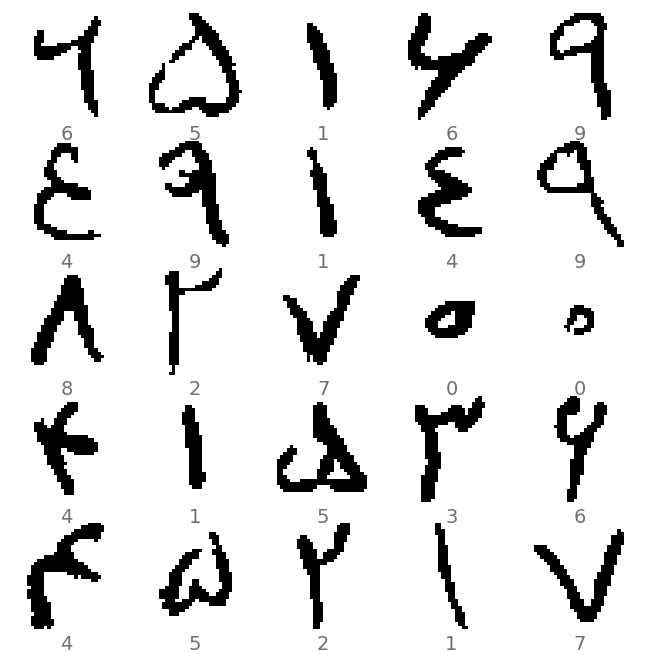

```python
plt.figure(figsize=(8, 8))
for i in range(25):
    plt.subplot(5, 5, i+1)
    plt.xticks([])
    plt.yticks([])
    plt.grid(False)
    plt.imshow(x_train[i], cmap=plt.cm.binary)
    plt.xlabel(str(y_train[i]))
plt.show()
```

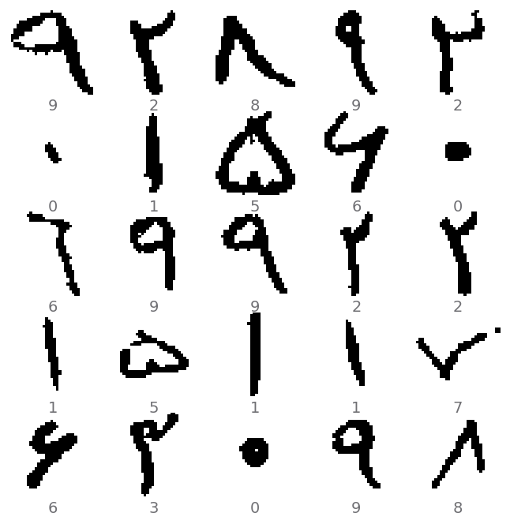

```python
plt.figure(figsize=(8, 8))
for i in range(25):
    plt.subplot(5, 5, i+1)
    plt.xticks([])
    plt.yticks([])
    plt.grid(False)
    plt.imshow(x_test[i], cmap=plt.cm.binary)
    plt.xlabel(str(y_test[i]))
plt.show()
```

# Preprocessing

```python
n1 = np.random.rand(3, 4, 5)
n1.shape # 3: number 4: w, 5:h

numb, w, h = n1.shape
n2 = np.reshape(n1, (numb, w, h, 1))
n2.shape
```

```
(3, 4, 5, 1)
```

```python
x_train_ext = np.reshape(x_train,
                         (x_train.shape[0], x_train.shape[1], x_train.shape[2], 1))


x_test_ext = np.reshape(x_test,
                         (x_test.shape[0], x_test.shape[1], x_test.shape[2], 1))


x_valid_ext = np.reshape(x_valid,
                         (x_valid.shape[0], x_valid.shape[1], x_valid.shape[2], 1))

print(x_train_ext.shape)
print(x_test_ext.shape)
print(x_valid_ext.shape)
```

```
(57000, 32, 32, 1)
(20000, 32, 32, 1)
(3000, 32, 32, 1)
```

```python
c2 = tf.keras.layers.Conv2D(16, (3, 3), input_shape=(32, 32, 1), activation='relu')
c2
```

```
<tensorflow.python.keras.layers.convolutional.Conv2D at 0x7f9e12fb0ba8>
```

```python
x_train_ext[0].shape
```

```
(32, 32, 1)
```

```python
o = c2([x_train_ext[0]])
```

```python
# o
```

# Arch

```python
def build_model(dnn_units):
    model, r, evaluate = None, None, None

    model = tf.keras.Sequential([

        # c2d - #1
        tf.keras.layers.Conv2D(16, (3, 3),
                               input_shape=(32, 32, 1),
                               activation='relu'),
        tf.keras.layers.MaxPool2D((2, 2)),

        # c2d - #2
        tf.keras.layers.Conv2D(32, (3, 3),
                               activation='relu'),
        tf.keras.layers.MaxPool2D((2, 2)),

        # c2d - #3
        tf.keras.layers.Conv2D(32, (3, 3),
                               activation='relu'),
        tf.keras.layers.MaxPool2D((2, 2)),

        # flatten
        tf.keras.layers.Flatten(),

        # fc
        tf.keras.layers.Dense(dnn_units, activation='relu'),

        # softmax
        tf.keras.layers.Dense(10, activation='softmax')
    ])

    model.compile(optimizer='adam',
                  loss='sparse_categorical_crossentropy',
                  metrics=['accuracy'])


    r = model.fit(x_train_ext, y_train,
                  validation_data=[x_valid_ext, y_valid],
                  epochs=10,
                  batch_size=128,
                  verbose=1)


    evaluate = model.evaluate(x_test_ext, y_test, verbose=0)

    model.summary()

    return model, r, evaluate
```

```python
model, r, evaluate = build_model(64)
evaluate
```

```
Train on 57000 samples, validate on 3000 samples
Model: "sequential_1"
_________________________________________________________________
Layer (type)                 Output Shape              Param #
=================================================================
conv2d_5 (Conv2D)            (None, 30, 30, 16)        160
_________________________________________________________________
max_pooling2d_3 (MaxPooling2 (None, 15, 15, 16)        0
_________________________________________________________________
conv2d_6 (Conv2D)            (None, 13, 13, 32)        4640
_________________________________________________________________
max_pooling2d_4 (MaxPooling2 (None, 6, 6, 32)          0
_________________________________________________________________
conv2d_7 (Conv2D)            (None, 4, 4, 32)          9248
_________________________________________________________________
max_pooling2d_5 (MaxPooling2 (None, 2, 2, 32)          0
_________________________________________________________________
flatten_1 (Flatten)          (None, 128)               0
_________________________________________________________________
dense_2 (Dense)              (None, 64)                8256
_________________________________________________________________
dense_3 (Dense)              (None, 10)                650
=================================================================
Total params: 22,954
Trainable params: 22,954
Non-trainable params: 0
_________________________________________________________________
```

```
[0.05064906008446123, 0.9848]
```

```python
# classification report
p = model.predict(x_test_ext)
p = np.argmax(p, axis=1)

print(classification_report(y_test, p))
```

```
              precision    recall  f1-score   support

           0       1.00      0.99      0.99      2000
           1       0.99      1.00      0.99      2000
           2       0.96      0.98      0.97      2000
           3       0.99      0.94      0.96      2000
           4       0.97      0.99      0.98      2000
           5       0.98      1.00      0.99      2000
           6       0.98      0.99      0.99      2000
           7       1.00      0.99      1.00      2000
           8       1.00      0.99      0.99      2000
           9       0.99      0.98      0.99      2000

    accuracy                           0.98     20000
   macro avg       0.99      0.98      0.98     20000
weighted avg       0.99      0.98      0.98     20000
```

# Tensorboard

## Hyperparams Tuning

```python
def train_test_model(hparams):
    model = None
    accuracy = 0

    return accuracy
```

```python
from datetime import datetime

!rm -rf ./logs/
logdir = 'logs/scaler/' + datetime.now().strftime('%Y%m%d-%H%M%S')
```

```python
from tensorboard.plugins.hparams import api as hp


HP_DNN_UNITS = hp.HParam('dnn_units', hp.Discrete([16, 32, 64]))
HP_DROPOUT = hp.HParam('dropout', hp.RealInterval(0.1, 0.4))
HP_OPTIMIZER = hp.HParam('optimizer', hp.Discrete(['adam', 'rmsprop', 'sgd']))
METRIC_ACCURACY = 'accuracy'

with tf.summary.create_file_writer(logdir + '/hparam').as_default():
    hp.hparams_config(
        hparams=[HP_DNN_UNITS, HP_DROPOUT, HP_OPTIMIZER],
        metrics=[hp.Metric(METRIC_ACCURACY, display_name='Accuracy')],
    )
```

```python
def run(run_dir, hparams):
    with tf.summary.create_file_writer(run_dir).as_default():
        hp.hparams(hparams)  # record the values used in this trial
        accuracy = train_test_model(hparams)
        tf.summary.scalar(METRIC_ACCURACY, accuracy, step=1)
```

```python
session_num = 0

for num_units in HP_DNN_UNITS.domain.values:
    for dropout_rate in (HP_DROPOUT.domain.min_value, HP_DROPOUT.domain.max_value):
        for optimizer in HP_OPTIMIZER.domain.values:
            hparams = {
                HP_DNN_UNITS: num_units,
                HP_DROPOUT: dropout_rate,
                HP_OPTIMIZER: optimizer,
            }
            run_name = "run-%d" % session_num
            print('--- Starting trial: %s' % run_name)
            print({h.name: hparams[h] for h in hparams})
            run(logdir + '/hparam/' + run_name, hparams)
            session_num += 1
```

[output not shown]

## After Tuning

```python
def build_optimal_model():
    model = None

    return model
```

```python
optimal_model = build_optimal_model()
```

```python
from datetime import datetime

!rm -rf ./logs/
logdir = 'logs/scaler/' + datetime.now().strftime('%Y%m%d-%H%M%S')
```

```python
class ImagePredictionCallBack(tf.keras.callbacks.Callback):

    def __init__(self, log_dir, model):
        super(ImagePredictionCallBack, self).__init__()
```

```python
ig_cb = ImagePredictionCallBack(log_dir=logdir, model=optimal_model)
tb_cb = tf.keras.callbacks.TensorBoard(log_dir=logdir, histogram_freq=1)
```

```python
r = optimal_model.fit(x_train_ext, y_train,
              validation_data=[x_valid_ext, y_valid],
              epochs=2,
              batch_size=128,
              callbacks=[tb_cb, ig_cb],
              verbose=1)
```

## Tensorboard

```python
# %tensorboard --logdir logs/scaler/
```